# hw4_Lab

#### Homework 4

Marina Bosi  
Music 320 - Fall 2025

## Lab assignment (40 points)

## Spectrogram Implementation and Peak Detection

# Problem 1: Implement a Spectrogram function

In this problem, we will implement a simplified version of the `matplotlib.specgram()` and the `scipy.signal.spectrogram()` function and use it to track the location of spectral peaks over time.

## Create a `Spectrogram()` function

Create a `spectrogram(x, fs, N)` function where the arguments are a mono input signal, x, (i.e. a long vector of sample values x[n]) whose samples are normalized between $-1$ and $1$, the sampling rate fs in Hz, and the block size N long. The function should iterate through the signal taking chunks of $N/2$ new samples each step.

Make sure you input signal x[n] starts with an extra block of N/2 zeroes and append at the end another N/2 zeros (plus however many zeros are needed to extend the signal to an integer number of N/2 blocks) before processing it. Start the process with a pointer to the beginning of the zero-padded signal, take a block of N samples, process them (i.e., window them, take their FFT, and include the corresponding psd as that time step’s Sxx), and repeat the process, moving the data pointer forward by N/2 samples (hop size) for each block until you process the block that reaches the end of the zero-padded signal.

Knowing $N/2$ and the overall number of samples `len(x)`, you should be able to figure out how many blocks you will process. Consider the time of the first block (the one with $N/2$ zeros and the first $N/2$ samples) to be zero and increment the time for each subseequent block by $N/2 * 1/fs$ (the time interval of a half-block of samples). Knowing the number of blocks you will process means you should be able to create a vector $t$ which represents the time in seconds of the center for each N-long block you will process. (Don't forget about the last block where you are combining the last data samples with $N/2$ zeroes.)

Given the length of the DFT, $N$, you know that there will be $N/2$ positive frequency lines at frequencies $k \frac{fs}{N}$ for $k \in \{0,1,...,N/2-1\}$. This means you should be able to create a vector $f$ which is the frequency in Hz of each positive-frequency line computed.

At each step you will be storing the power spectral density associated with each positive frequency line. Hence, we know that we will need a matrix `Sxx` to store that data that has $N/2$ rows (one row for each positive frequency) and `len(t)` columns (one column for each block processed).

Starting at the beginning of the data file (after adding the initial $N/2$ zeros to x[n]) for each step, you will:  
(a) get the current block $y[n]$ of $N$ samples from the zero-padded $x[n]$; increment the data pointer by $N/2$ (hop size)  
(b) window $y[n]$ with an N-long Hanning window $w_h[n]$ to get $yw[n] = y[n] * w_h[n]$  
(c) take the DFT $YW[k]$ of $yw[n]$  
(d) compute the psd `Sxx = np.abs(YW)**2 * 8/3 * 4/N**2` (what goes into the `10*np.log10()` in the DBFS formula) and store it as the current column of `Sxx`

After all of the steps, return the following tuple: `(f, t, Sxx)`

## Test your `spectrogram()` function

Start by passing your spectrogram function a full-scale 1 kHz sinusoid with amplitude normalized to $1$ and sampling rate of 44.100 kHz.

Convert `Sxx` into dBFS by taking `10. * np.log10()` of it and plot a column of `Sxx` in dBFS against the vector `f` your function returned. Make sure that the frequency of the peak is in the right place (1 kHz) and the peak is the correct height (approching zero dBFS).

Now make a "colormesh" image of your spectrogram output using the following command: `plt.pcolormesh(t, f, 10 * np.log10(Sxx)), shading='gouraud')` where (as customary), `plt` is an alias for `matplotlib.pyplot`. This will create an image plot where the x-axis is time, the y-axis is frequency, and the color at any point is based on the dBFS value of the spectral density. (The shading choice linearly interpolates between the time-frequency points where there is spectral densitiy data to get a smooth picture of the spectral content.)

Finally, read the SQAM disk file "14.wav" (oboe). Take just the left channel and the first 10 seconds of content, normalized it so that the amplitudes are between $-1$ and $1$ (python's wav read function by default return integers between $-2^{15}$ and $2^{15}-1$) and pass it to your `spectrogram()` function, making the same two graphs you made for the 1 kHz sinusoid. I recommend trying N = 4096.

## Peak detection

The output of your spectrogram function gives the power spectral density for a set of points in time (i.e., each column). In this step, you will find the large peaks that you can see in the dB graph and in the colormesh image.

Create a function which takes the power spectral density at one point in time (i.e., one column of `Sxx`) and returns the frequencies and power spectral densities of the main spectral peaks in that column. (You may find the function `scipy.signal.find_peaks()` to be helpful here.) For each identified peak, combine the power spectral density of the peak with its two near-neighbors (i.e., if the index of the peak is $i$, add the psd for $i, i-1, i+1$) to get an estimate of the power spectral density integrated over the peak and compute the spectral-density-weighted average of the frequencies of those three lines to get an estimate of the peak frequency:

$peakFreq[i] = (psd[i]*f[i] + psd[i-1]*f[i-1] + psd[i+1]*f[i+1])/(psd[i] + psd[i-1] + psd[i+1])$)

If your peak amplitudes are `peakAmp` and your peak frequencies are `peakFreq`, have your function return `(peakAmp, peakFreq)`. Try to tune your peak detection so it only sees the dominant spectral peaks.

Now use the output of your spectrogram function applied to the 10 s oboe excerpt and, for each time $t$, find all of the peaks and their frequencies at that point in time. (You may find it useful to do this using a "list comprehension" where each element is the output of the peak finding function at one column of `Sxx` .)

Lastly, make a graph that shows time $t$ on the x-axis and frequency on the y-axis. Loop over times and, at each time, plot a point for the frequency of each peak you found at that time. The result should look like a dot-version of your spectrogram (see example below).

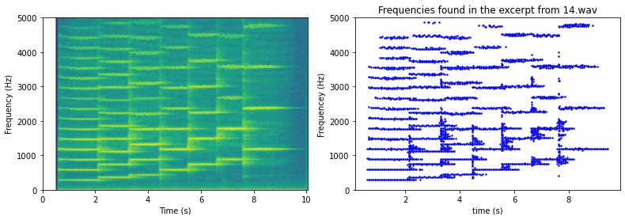